# Modeling and prediction for movies

# title: “Course3PeerAssignment”

# author: “GaryFH”

# date: “May 15, 2018”

# output: html_document

## Setup

### Load packages

```r
suppressWarnings(library(ggplot2))
suppressWarnings(library(statsr))
suppressWarnings(library(knitr))
suppressWarnings(library(dplyr))
suppressWarnings(library(tidyr))
options(scipen=999,digits = 3)
suppressWarnings(library(gridExtra))
suppressWarnings(library(data.table))
suppressWarnings(library(readr))
suppressWarnings(library(stringi))
suppressWarnings(library(grid))
suppressWarnings(library(gtable))
suppressWarnings(library(devtools))
suppressWarnings(library(GGally))
gh <- function(x, d=2) sprintf(paste0("%1.",d,"f"), x)
```

### Load data

```r
load("_e1fe0c85abec6f73c72d73926884eaca_movies.Rdata")
d1<-movies
```

## Part 1: Data

### **TASK:**

#### Assignment is to learn what attributes make a movie popular with the goal of creating a predictive algorithm with the response variable being a movies popularity.

##### Quoted from the *Codebook for Movies dataset*: “The data set is comprised of 651 randomly sampled movies produced and released before 2016. Some of these variables are only there for informational purposes and do not make any sense to include in a statistical analysis.”

##### Note that after Exploratory data analysis and preliminary preprocessing of the dataframe, **the number of variables** used for statistical analysis was **reduced from 32 down to only 11**.

## Part 2: Research question

#### As a Data Scientist for a movie studio it is important to provide my employer with evidence to help improve the odds that the movies we produce will be popular. Therefore the **Primary Question is**: What linear regression model best predicts a movie’s popularity - note that this data only allows for correlation predictions and should not be considered to imply causality.

#### Sub questions:

##### What accuracy can be expected from this model?

##### Have you insured predictor variables are not collinear?

##### Have you provided evidence of correlation between predictor and responce variable?

## Part 3: Exploratory data analysis

```r
print(paste("The movie database is of the class: ",class(d1)[1], "a type of dataframe" ))
```

```
## [1] "The movie database is of the class:  tbl_df a type of dataframe"
```

```r
print(paste("The dimensions of the movie database are;", dim(d1)[1],"rows and ",dim(d1)[2]," columns"))
```

```
## [1] "The dimensions of the movie database are; 651 rows and  32  columns"
```

```r
print("Following is a list of all movie variables and their class - shown in parenthesis")
```

```
## [1] "Following is a list of all movie variables and their class - shown in parenthesis"
```

```r
sapply(d1,class)
```

```
##            title       title_type            genre          runtime
##      "character"         "factor"         "factor"        "numeric"
##      mpaa_rating           studio    thtr_rel_year   thtr_rel_month
##         "factor"         "factor"        "numeric"        "numeric"
##     thtr_rel_day     dvd_rel_year    dvd_rel_month      dvd_rel_day
##        "numeric"        "numeric"        "numeric"        "numeric"
##      imdb_rating   imdb_num_votes   critics_rating    critics_score
##        "numeric"        "integer"         "factor"        "numeric"
##  audience_rating   audience_score     best_pic_nom     best_pic_win
##         "factor"        "numeric"         "factor"         "factor"
##   best_actor_win best_actress_win     best_dir_win       top200_box
##         "factor"         "factor"         "factor"         "factor"
##         director           actor1           actor2           actor3
##      "character"      "character"      "character"      "character"
##           actor4           actor5         imdb_url           rt_url
##      "character"      "character"      "character"      "character"
```

#### **Second**, remove excluded variables as explained above.

```r
d2<-select(d1,-starts_with("actor"),-rt_url,-imdb_url,-audience_rating,-critics_rating,-studio,  -thtr_rel_year, -dvd_rel_year, -critics_score, -best_pic_nom, -director,-top200_box,
-imdb_num_votes,-dvd_rel_day,-critics_rating,-dvd_rel_month,-thtr_rel_day,-best_pic_win)
print(paste("The number of variables in the processed dataframe:",ncol(d2)))
```

```
## [1] "The number of variables in the processed dataframe: 11"
```

```r
print("The names of the variables in the processed dataframe are:")
```

```
## [1] "The names of the variables in the processed dataframe are:"
```

```r
names(d2)
```

```
##  [1] "title"            "title_type"       "genre"
##  [4] "runtime"          "mpaa_rating"      "thtr_rel_month"
##  [7] "imdb_rating"      "audience_score"   "best_actor_win"
## [10] "best_actress_win" "best_dir_win"
```

#### **Third**, provide summary statistics for all numeric variables

##### Note that this code turns “ugly” summary printouts into one attractive table

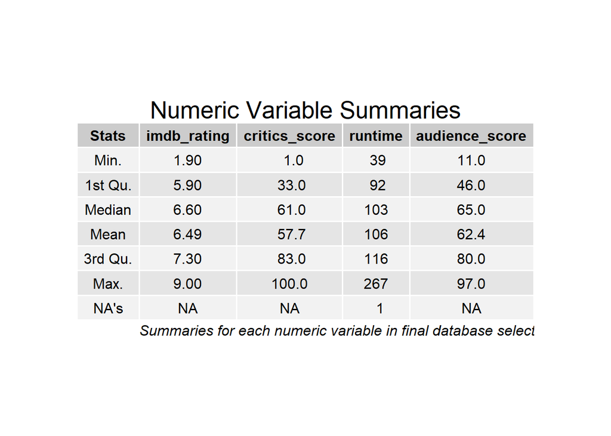

```r
    d2b<-select_if(d1,is.numeric)

    bb<-summary(d2b$audience_score)
    bg<-as.matrix(bb)
    bg<-as.data.frame(bg)
    Stats<-rownames(bg)
    bb<-cbind(Stats,bg)
    c0<-tbl_df(bb)
    names(c0)=c("Stats","audience_score")

    bb<-summary(d2b$imdb_rating)
    bg<-as.matrix(bb)
    bg<-as.data.frame(bg)
    Stats<-rownames(bg)
    bb<-cbind(Stats,bg)
    c1<-tbl_df(bb)
    names(c1)=c("Stats","imdb_rating")


    bb<-summary(d2b$critics_score)
    bg<-as.matrix(bb)
    bg<-as.data.frame(bg)
    Stats<-rownames(bg)
    bb<-cbind(Stats,bg)
    c2<-tbl_df(bb)
    names(c2)=c("Stats","critics_score")

    bb<-summary(d2b$runtime)
    bg<-as.matrix(bb)
    bg<-as.data.frame(bg)
    Stats<-rownames(bg)
    bb<-cbind(Stats,bg)
    c3<-tbl_df(bb)
    names(c3)=c("Stats","runtime")


    dd<-full_join(c1,c2,by="Stats")
    dd<-full_join(dd,c3,by="Stats")
    dd<-full_join(dd,c0,by="Stats")


        table2<-tableGrob(dd,rows = NULL)
        title <- textGrob("Numeric Variable Summaries",gp=gpar(fontsize=20))
        footnote <- textGrob("Summaries for each numeric variable in final database selected", x=0, hjust=0, gp=gpar(fontsize=12, fontface="italic"))

        padding <- unit(0.5,"line")
        table2 <- gtable_add_rows(table2,
                         heights = grobHeight(title) + padding,
                         pos = 0)
        table2 <- gtable_add_rows(table2,
                         heights = grobHeight(footnote)+ padding)
        table2 <- gtable_add_grob(table2, list(title, footnote),
                         t=c(1, nrow(table2)), l=c(1,2),
                         r=ncol(table2))

        grid.newpage()
  grid.draw(table2)
```

#### **Fourth**, provide overview graphs of dataframe

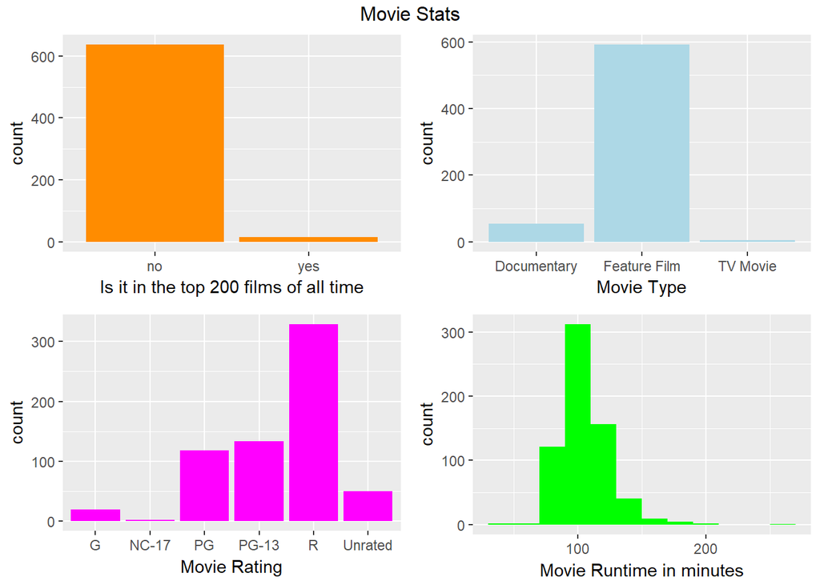

```r
p1 <- ggplot(d1, aes(x=top200_box)) +
      geom_bar(fill="dark orange") +
      xlab("Is it in the top 200 films of all time")
p2 <- ggplot(d1, aes(x=title_type)) +
      geom_bar(fill="light blue") +
      xlab("Movie Type")
p3 <- ggplot(d1, aes(x=mpaa_rating)) +
      geom_bar(fill="magenta") +
      xlab("Movie Rating")
p4 <- ggplot(d1, aes(x=runtime)) +
      geom_histogram(binwidth=20, fill="green") +
      xlab("Movie Runtime in minutes")
grid.arrange(p1, p2, p3, p4, nrow=2,
             top="Movie Stats")
```

## Part 4: Modeling

#### The *“Popularity”* variable is determined by “audience_score” (audience_rating is less accurate) and imdb_rating. A new variable name *“Popularity”* was created and used as the **“Response Variable”**. The **“Popularity”** variable combines *audience_score* (possible values 0-100) plus 10**imdb_rating* (times 10 since possible values for *imdb_rating* are only 0-10).

```r
d3<-mutate(d2,popularity=(audience_score+(imdb_rating*10)))
d3<-select(d3,popularity,everything())
d4<-select(d3,-audience_score,-imdb_rating)
print("The predictor variable names of the database used in developing the model are:")
```

```
## [1] "The predictor variable names of the database used in developing the model are:"
```

```r
names(d4[3:10])
```

```
## [1] "title_type"       "genre"            "runtime"
## [4] "mpaa_rating"      "thtr_rel_month"   "best_actor_win"
## [7] "best_actress_win" "best_dir_win"
```

```r
summary(d4$popularity)
```

```
##    Min. 1st Qu.  Median    Mean 3rd Qu.    Max.
##      35     105     131     127     152     187
```

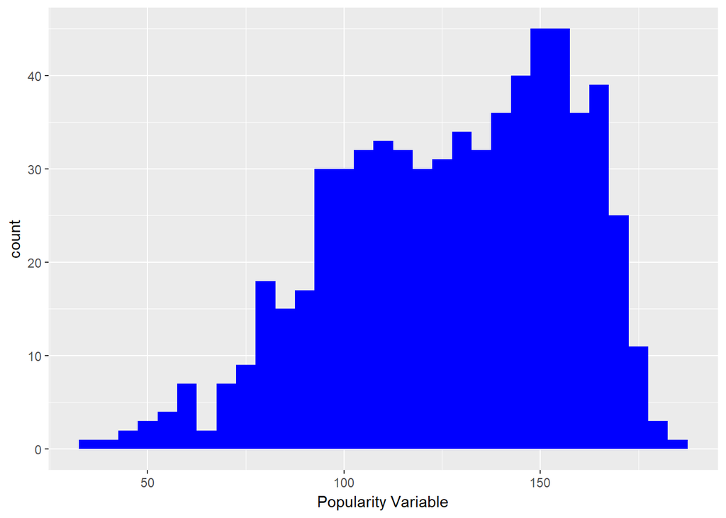

```r
p3 <- ggplot(d4, aes(x=popularity)) +
      geom_histogram(binwidth=5, fill="blue") +
      xlab("Popularity Variable")
p3
```

#### A linear regression model is made using all the variables

```r
allvar<-lm(popularity~title_type+genre+runtime+mpaa_rating+
        best_actor_win+best_actress_win+best_dir_win+thtr_rel_month,d4)
summary(allvar)
```

```
##
## Call:
## lm(formula = popularity ~ title_type + genre + runtime + mpaa_rating +
##     best_actor_win + best_actress_win + best_dir_win + thtr_rel_month,
##     data = d4)
##
## Residuals:
##    Min     1Q Median     3Q    Max
## -87.35 -17.45   2.69  18.89  58.86
##
## Coefficients:
##                                 Estimate Std. Error t value
## (Intercept)                    118.68480   13.09711    9.06
## title_typeFeature Film         -19.80368    9.61230   -2.06
## title_typeTV Movie             -35.44802   15.14205   -2.34
## genreAnimation                   1.82368   10.13415    0.18
## genreArt House & International  15.69601    7.83895    2.00
## genreComedy                      0.00283    4.34136    0.00
## genreDocumentary                25.69038   10.32040    2.49
## genreDrama                      16.94365    3.68678    4.60
## genreHorror                     -8.03653    6.46792   -1.24
## genreMusical & Performing Arts  28.66720    8.79806    3.26
## genreMystery & Suspense          4.98453    4.84460    1.03
## genreOther                      17.98659    7.33460    2.45
## genreScience Fiction & Fantasy  -6.68502    9.24103   -0.72
## runtime                          0.30299    0.06172    4.91
## mpaa_ratingNC-17               -14.98252   19.68187   -0.76
## mpaa_ratingPG                  -16.40776    7.12436   -2.30
## mpaa_ratingPG-13               -24.75652    7.27428   -3.40
## mpaa_ratingR                   -15.98527    7.05564   -2.27
## mpaa_ratingUnrated             -11.17425    8.14880   -1.37
## best_actor_winyes               -1.02499    3.07492   -0.33
## best_actress_winyes              0.75545    3.38242    0.22
## best_dir_winyes                 10.23062    4.25388    2.41
## thtr_rel_month                  -0.02567    0.29743   -0.09
##                                            Pr(>|t|)
## (Intercept)                    < 0.0000000000000002 ***
## title_typeFeature Film                      0.03979 *
## title_typeTV Movie                          0.01954 *
## genreAnimation                              0.85725
```

[output cut: 11 more lines]

```
## mpaa_ratingPG                               0.02160 *
## mpaa_ratingPG-13                            0.00071 ***
## mpaa_ratingR                                0.02382 *
## mpaa_ratingUnrated                          0.17078
## best_actor_winyes                           0.73899
## best_actress_winyes                         0.82334
## best_dir_winyes                             0.01646 *
## thtr_rel_month                              0.93124
## ---
## Signif. codes:  0 '***' 0.001 '**' 0.01 '*' 0.05 '.' 0.1 ' ' 1
##
## Residual standard error: 25.9 on 627 degrees of freedom
##   (1 observation deleted due to missingness)
## Multiple R-squared:  0.284,  Adjusted R-squared:  0.259
## F-statistic: 11.3 on 22 and 627 DF,  p-value: <0.0000000000000002
```

```r
anova(allvar)
```

```
## Analysis of Variance Table
##
## Response: popularity
##                   Df Sum Sq Mean Sq F value               Pr(>F)
## title_type         2  64084   32042   47.66 < 0.0000000000000002 ***
## genre             10  66769    6677    9.93   0.0000000000000015 ***
## runtime            1  19398   19398   28.85   0.0000001101637706 ***
## mpaa_rating        5  12792    2558    3.81               0.0021 **
## best_actor_win     1     40      40    0.06               0.8080
## best_actress_win   1     58      58    0.09               0.7698
## best_dir_win       1   3885    3885    5.78               0.0165 *
## thtr_rel_month     1      5       5    0.01               0.9312
## Residuals        627 421523     672
## ---
## Signif. codes:  0 '***' 0.001 '**' 0.01 '*' 0.05 '.' 0.1 ' ' 1
```

#### Remove variables with high (over .05) p-Values one at a time, starting with the highest. Rerun anova after each removal and repeat until all variables with p-Values over .05 are gone.

```r
#remove thtr_rel_month from full model first
mod1<-lm(popularity~title_type+genre+runtime+mpaa_rating+
        best_actor_win+best_actress_win+best_dir_win,d4)
anova(mod1)
```

```
## Analysis of Variance Table
##
## Response: popularity
##                   Df Sum Sq Mean Sq F value               Pr(>F)
## title_type         2  64084   32042   47.74 < 0.0000000000000002 ***
## genre             10  66769    6677    9.95   0.0000000000000014 ***
## runtime            1  19398   19398   28.90   0.0000001076508793 ***
## mpaa_rating        5  12792    2558    3.81               0.0021 **
## best_actor_win     1     40      40    0.06               0.8079
## best_actress_win   1     58      58    0.09               0.7696
## best_dir_win       1   3885    3885    5.79               0.0164 *
## Residuals        628 421528     671
## ---
## Signif. codes:  0 '***' 0.001 '**' 0.01 '*' 0.05 '.' 0.1 ' ' 1
```

```r
#remove best_actor_win next
mod2<-lm(popularity~title_type+genre+runtime+mpaa_rating+best_actress_win+best_dir_win,d4)
anova(mod2)
```

```
## Analysis of Variance Table
##
## Response: popularity
##                   Df Sum Sq Mean Sq F value               Pr(>F)
## title_type         2  64084   32042   47.80 < 0.0000000000000002 ***
## genre             10  66769    6677    9.96   0.0000000000000013 ***
## runtime            1  19398   19398   28.94   0.0000001054504319 ***
## mpaa_rating        5  12792    2558    3.82               0.0021 **
## best_actress_win   1     51      51    0.08               0.7825
## best_dir_win       1   3854    3854    5.75               0.0168 *
## Residuals        629 421604     670
## ---
## Signif. codes:  0 '***' 0.001 '**' 0.01 '*' 0.05 '.' 0.1 ' ' 1
```

```r
#remove best_actress_win next
mod3<-lm(popularity~title_type+genre+runtime+mpaa_rating+best_dir_win,d4)
anova(mod3)
```

```
## Analysis of Variance Table
##
## Response: popularity
##               Df Sum Sq Mean Sq F value               Pr(>F)
## title_type     2  64084   32042   47.88 < 0.0000000000000002 ***
## genre         10  66769    6677    9.98   0.0000000000000012 ***
## runtime        1  19398   19398   28.98   0.0000001031228800 ***
## mpaa_rating    5  12792    2558    3.82                0.002 **
## best_dir_win   1   3879    3879    5.80                0.016 *
## Residuals    630 421631     669
## ---
## Signif. codes:  0 '***' 0.001 '**' 0.01 '*' 0.05 '.' 0.1 ' ' 1
```

```r
#no more high P-Values;  therefore the final model is mod3

d5<-select(d4,-best_actress_win,-best_actor_win,-thtr_rel_month)
print("Following list are the names used in the final predictor model")
```

```
## [1] "Following list are the names used in the final predictor model"
```

```r
names(d5[3:7])#predictor variable names for final model
```

```
## [1] "title_type"   "genre"        "runtime"      "mpaa_rating"
## [5] "best_dir_win"
```

```r
finalmod<-mod3
gg<-summary(finalmod)
gg<-gg$r.squared
gg<-gh(gg,3)#gh is program loaded at top of this report for setting decimals
print(paste("Rsquared for the final model is:",gg,"- which does not indicate a strong model"))
```

```
## [1] "Rsquared for the final model is: 0.284 - which does not indicate a strong model"
```

### Verify that the final model is credible

#### 2) The residuals are **distributed around 0** - from the Residual Distribution Plot

#### 3) *Nearly normal residuals*: By looking at the histogram and Q-Q plot

#### 4) From Residuals Distribution Plot - Residuals have **constant variability**.

```r
#ggpairs(d5[3:4],columns = 1:2)


p1 <- ggplot(finalmod, aes(y=finalmod$residuals,x=finalmod$fitted.values)) +
      geom_point(color="dark green",size=1,alpha=.4) +
      geom_hline(yintercept = 0, linetype = "dashed") +
      xlab("Fitted values") +
      ylab("Residuals")

p2 <- ggplot(finalmod, aes(finalmod$residuals)) +
      geom_histogram(binwidth=8, fill="light green") +
      xlab("Residuals") +
      ggtitle("Residual Distribution")

p3 <- ggplot(finalmod, aes(sample=finalmod$residuals)) +
      stat_qq()  + xlab("Theoretical Quantiles")+ ylab("Residuals")
      ggtitle("Q-Q Plot")
```

```
## $title
## [1] "Q-Q Plot"
##
## $subtitle
## NULL
##
## attr(,"class")
## [1] "labels"
```

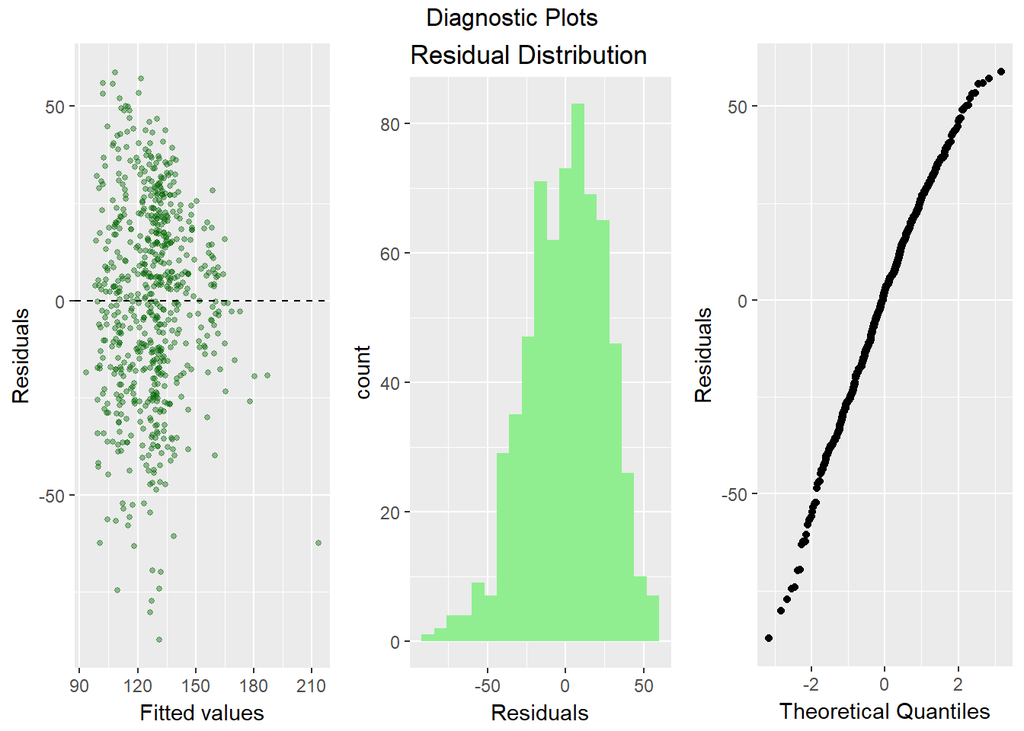

```r
      grid.arrange(p1, p2, p3, nrow=1, top="Diagnostic Plots")
```

## Part 5: Prediction

#### Apply finalmodel to predict popularity of two films released in 2017: **The Greatest Showman** and **Spider-Man: Homecoming**

```r
dShowman <- data.frame(title_type="Feature Film", genre="Drama", runtime=105, mpaa_rating="PG", best_dir_win="no")
ShowmanPred <- predict(finalmod, dShowman, interval="predict")
ShowmanAct<-87+(10*7.8)

dSpider <- data.frame(title_type="Feature Film", genre="Action & Adventure", runtime=133, mpaa_rating="PG-13", best_dir_win="no")
SpiderPred<- predict(finalmod, dSpider, interval="predict")
SpiderAct<-88+(10*7.5)
```

#### Spider-Man: Homecoming prediction Results - note actual rating is within 95% range

```r
gh <- function(x, d=2) sprintf(paste0("%1.",d,"f"), x)
print(paste("Predicted Rating",gh(SpiderPred[1]),"95% Range",gh(SpiderPred[2]),"-",gh(SpiderPred[3])," Actual Rating:",gh(SpiderAct)))
```

```
## [1] "Predicted Rating 114.08 95% Range 62.66 - 165.50  Actual Rating: 163.00"
```

### The Greatest Showman prediction Results - note actual rating is within 95% range

```r
print(paste("Predicted Rating",gh(ShowmanPred[1]),"95% Range",gh(ShowmanPred[2]),"-",gh(ShowmanPred[3])," Actual Rating:",gh(ShowmanAct)))
```

```
## [1] "Predicted Rating 130.97 95% Range 79.87 - 182.06  Actual Rating: 165.00"
```

## Part 6: Conclusion

#### 1) I was able to predict the popularity of a movie based on the final model

#### 2) The analysis shows that the model meets statistical standards and can be considered valid.

#### 3) Note that the Rsquared for the final is only .284 which indicates that only about 28% of the information that explains the response variable is found in this model. Ofcourse it is reasonable that the prediction of a hit movie is difficult - otherwise there wouldn’t be so many movies that aren’t popular enough to be successful.

#### 4) Creating separate models for each *title_type* and/or *genre* might help improve the model.